# Introduction to plotting in R

R is widely regarded to be a very powerful language for visualizing data. This may be due to the wide accessibly of the tool and the because many developers are working on libraries for data plotting in R. One such development is the `ggplot2` library which you already were introduced to in a few of the previous examples in this material.`ggplot2` is however not the only way to plot your data in R. R has built in plotting functionality and many functions that you use allow you to wrap them in plot and the author of the function has taken care of what the plot should look like. We’ll come back to plotting with `ggplot2` in a later lesson.

Let’s look at a few examples of base plotting.

```r
## Read in some data and clean it up:
pig_adg<- read.csv("pig_adg.csv")
pig_adg$ar_g1 <- NA
pig_adg$ar_g1[pig_adg$ar > 1] <- 1
pig_adg$ar_g1[pig_adg$ar <= 1] <- 0
pig_adg$ar_g1 <- factor(pig_adg$ar_g1, levels = c(0,1), labels = c("no atrophic", "yes atrophic"))
pig_adg$pn <- factor(pig_adg$pn, levels = c(0,1), labels = c("no pneumonia", "mild-severe pneumonia"))
pig_adg$sex <- factor(pig_adg$sex, levels = c(0,1), labels = c("female", "male"))
```

See what happens if you plot two variables in the dataframe:

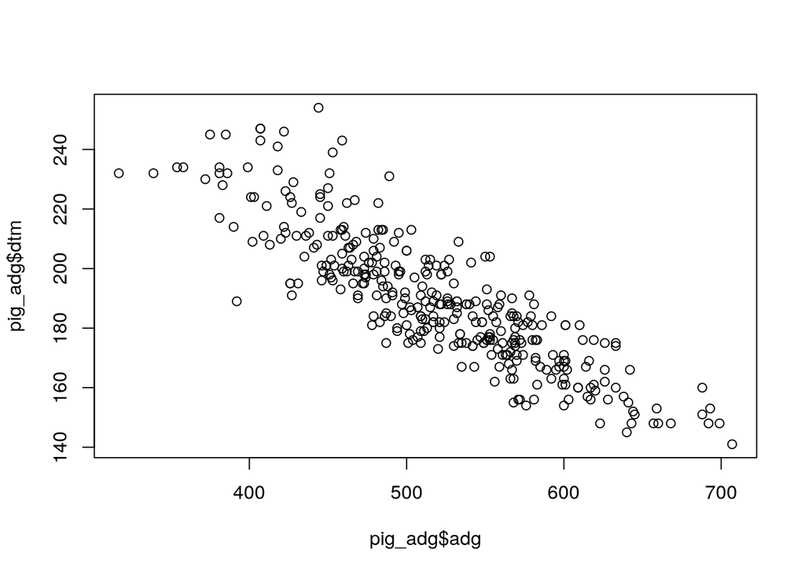

```r
plot(x = pig_adg$adg, y = pig_adg$dtm)
```

You get a scatter plot with the labels on the axis equal to the variable names. One of the default arguments that you do not see above is `type = "p"`. Let’s try `type = "l"`

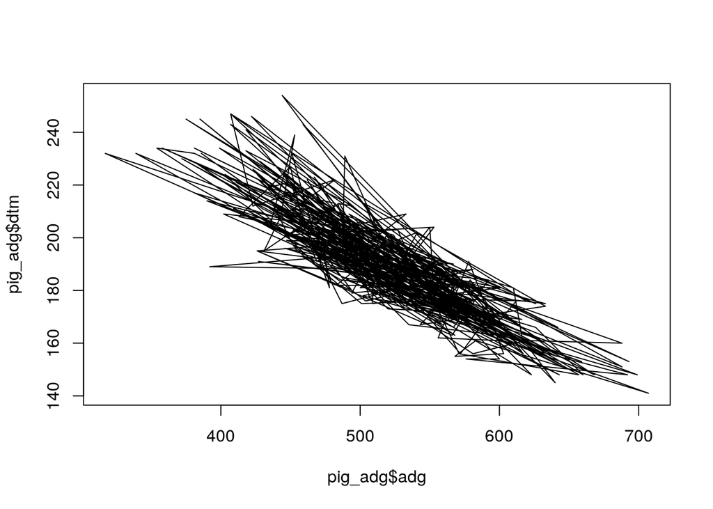

```r
plot(x = pig_adg$adg, y = pig_adg$dtm, type = "l")
```

That didn’t make much sense. We should probably sort the data by the x- variable first

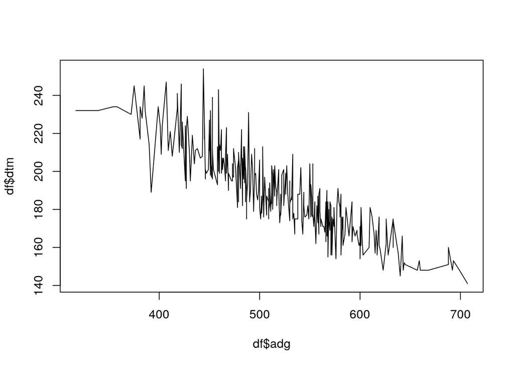

```r
df <- pig_adg[order(pig_adg$adg),]
plot(x = df$adg, y = df$dtm, type = "l")
```

We could also plot a model

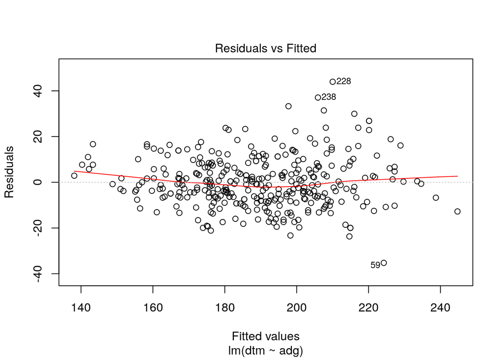

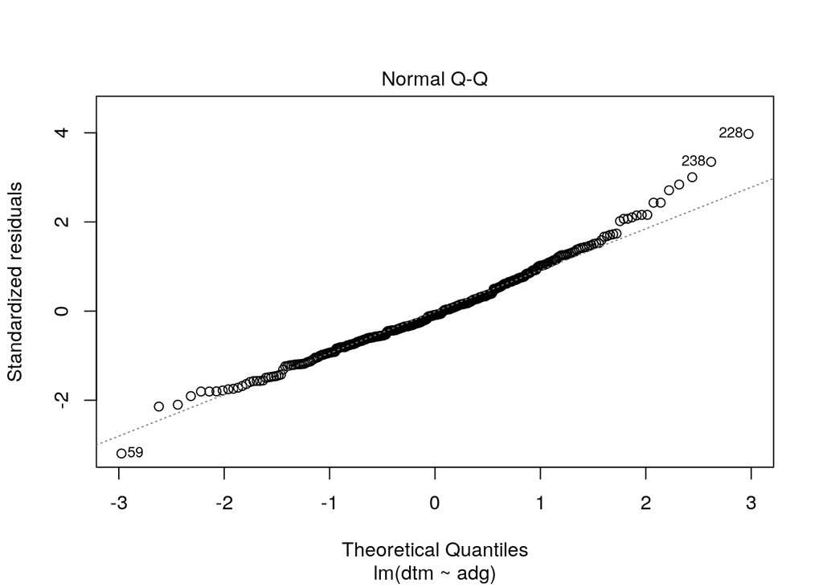

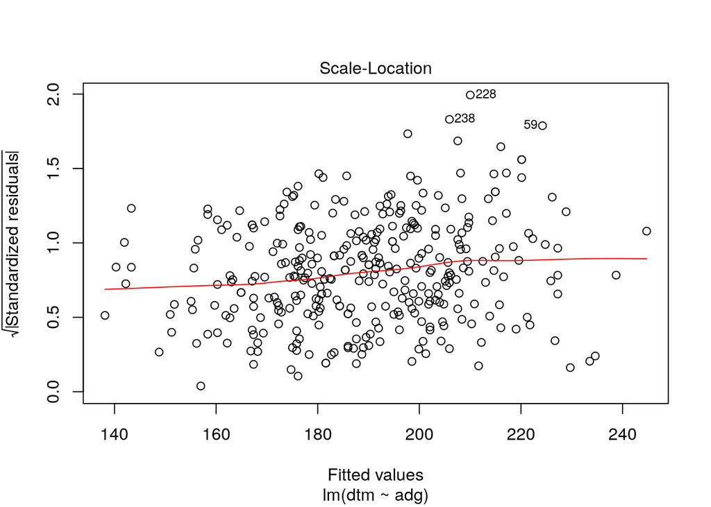

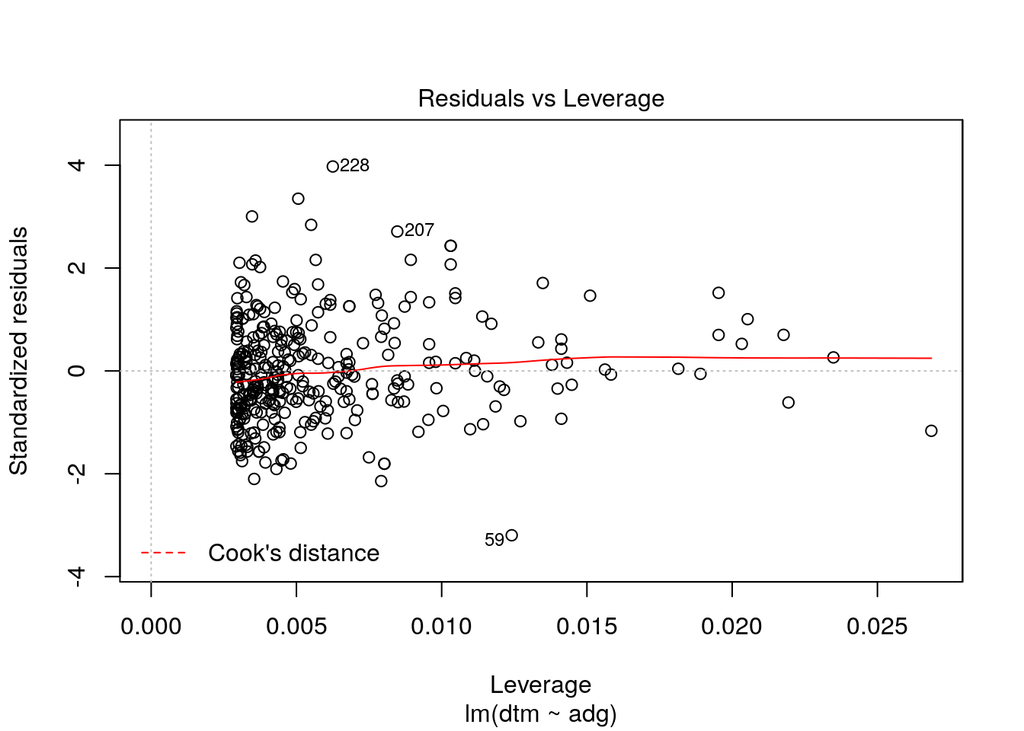

```r
plot(lm(formula = dtm ~ adg, data = pig_adg))
```

The code above is the `plot` function wrapped around the `lm` function (linear model). What we get back are the plots that the authors of `lm` felt would be most useful, in this case some plots of the residuals.

Many object types have an associated plot function that R knows how to employ. You should not be afraid to run plot on objects and see what you get back. Sometimes these plots are very useful and sometimes not.

## Basic plotting

We will run through how to do point (scatter), line, bar, and box plots.

# Scatter plot

Above you already saw the scatter plot.

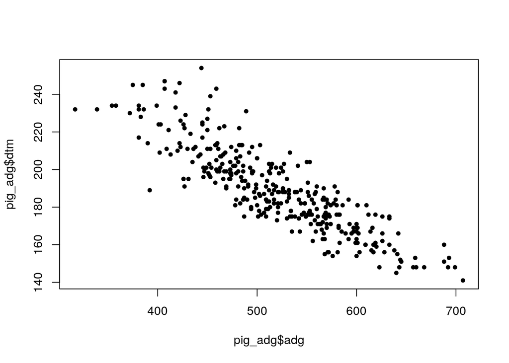

```r
plot(x = pig_adg$adg, y = pig_adg$dtm,
     type = "p", pch = 20
     )
```

In the above we are explicit about the `point` argument and change the plotting character with `pch`. You can use many different plotting characters in R.

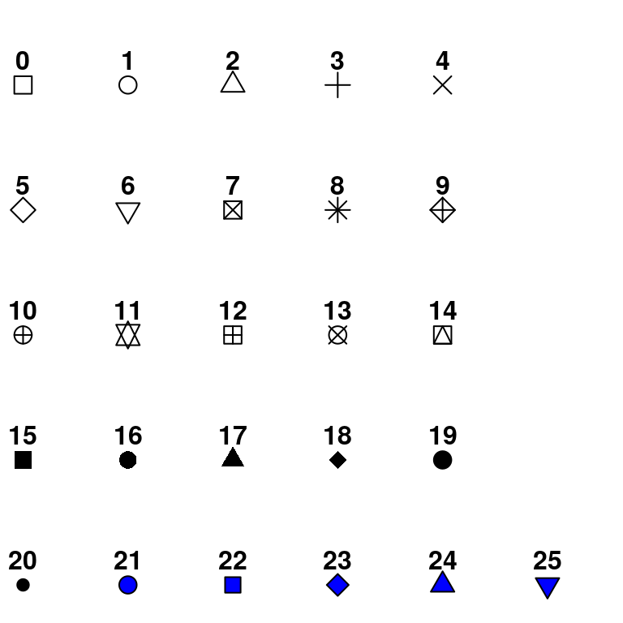

You can also set the colour of the points. The colours can be any of the available [text names](http://www.stat.columbia.edu/~tzheng/files/Rcolor.pdf) or a colour in [hexadecimal format](http://www.w3schools.com/tags/ref_colorpicker.asp).

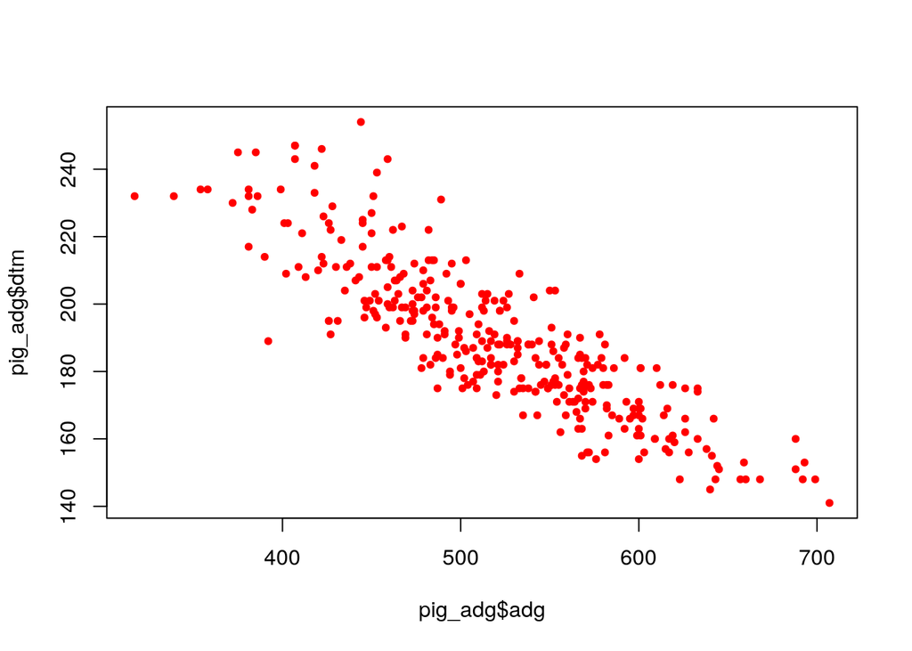

```r
plot(x = pig_adg$adg, y = pig_adg$dtm,
     type = "p", pch = 20, col = "red"
     )
```

We can change the axis titles.

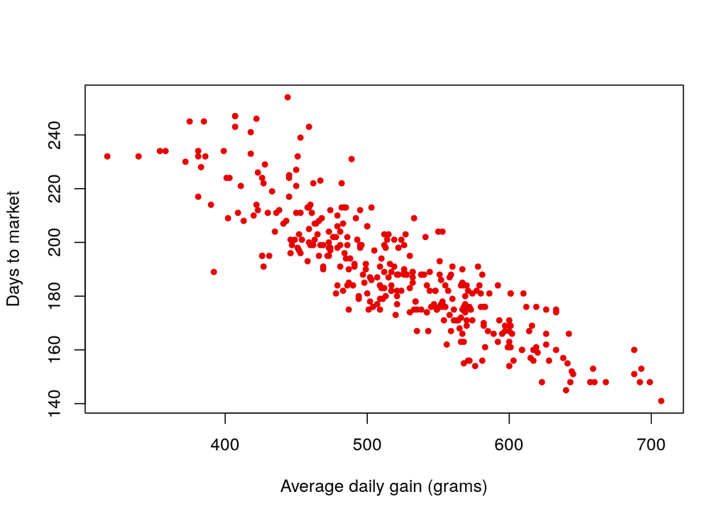

```r
plot(x = pig_adg$adg, y = pig_adg$dtm,
     type = "p", pch = 20, col = "#E60000",
     xlab = "Average daily gain (grams)",
     ylab = "Days to market"
     )
```

(Note we also are defining the red colour of the points above in hexadecimal.) Then we could change the tip marks and tick labels on the axis. We start by generating a plot without tick marks and then adding them with the axis function and defining the label orientation as well.

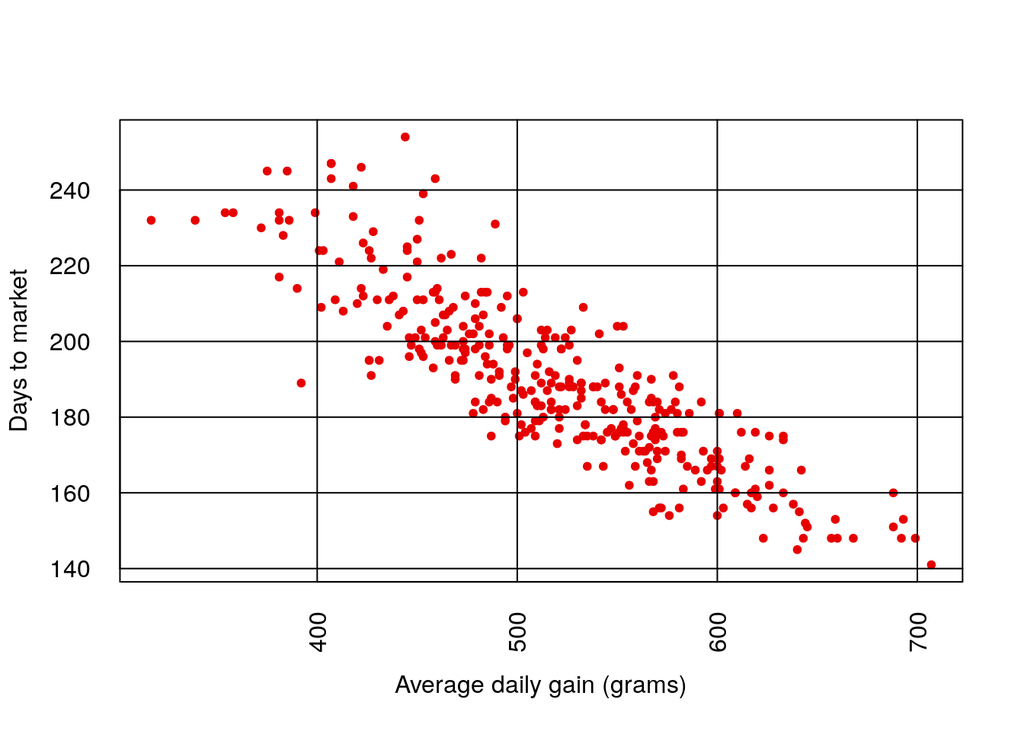

```r
plot(x = pig_adg$adg, y = pig_adg$dtm,
     type = "p", pch = 20, col = "#E60000",
     xlab = "Average daily gain (grams)",
     ylab = "Days to market",
     yaxt = "n", xaxt = "n"
     )

axis(side = 1, tck = 1, las = 2)
axis(side = 2, tck = 1, las = 2)
```

The `side` argument to the `axis` function defines which side of the graph you want an axis on (1=bottom, 2=left, 3=top, 4=right) and the `tch` argument the fraction of the plotting region that the tick should cover. The `las` argument gives the label orientation (0 = parallel, 2 = perpendicular). There are plenty of other things you can change about your graph and plenty of online tutorials to find the answers that you need to generate just the plot you want.

## The line plot

As we saw above in the introduction to basic plotting the line plot doesn’t really lend itself well to plotting the current dataset. We most often use it to plot a prediction, or a smoothed model or our data to lets quickly generate that so we have some data to work with.

```r
model <- lm(formula = dtm ~ adg, data = pig_adg)
predict_data <- data.frame("adg" = seq(min(pig_adg$adg), max(pig_adg$adg)))

predict_data$prediction_dtm <- predict(model, predict_data)
```

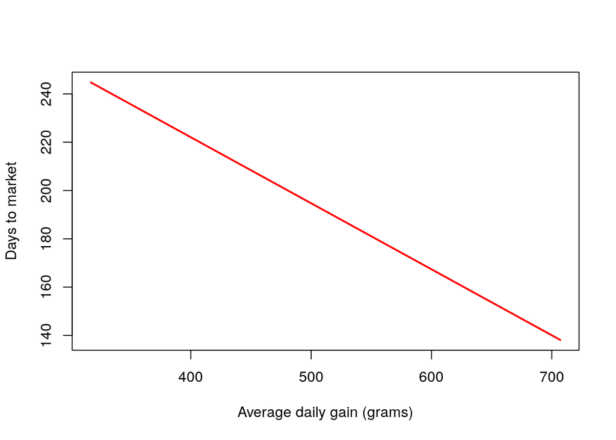

```r
plot(x = predict_data$adg, y = predict_data$prediction_dtm,
     type = "l", lwd = 2, col = "red",
     xlab = "Average daily gain (grams)",
     ylab = "Days to market")
```

Here we define the plot in much the same way as the `point` plot but use `type = "l"` and introduce another parameter specific to the `line` plot which is `lwd` or line weight. In this case 2 gives a slightly thicker line than the default 1.

You may wish to plot the prediction from you model ontop of the scattered points. You do this by first plotting the points and then overlaying the line.

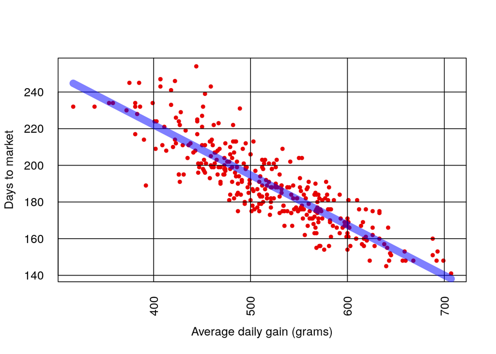

```r
plot(x    = pig_adg$adg,
     y    = pig_adg$dtm,
     type = "p",
     pch  = 20, col = "#E60000",
     xlab = "Average daily gain (grams)",
     ylab = "Days to market",
     yaxt = "n", xaxt = "n")

axis(side = 1, tck = 1, las = 2)
axis(side = 2, tck = 1, las = 2)

lines(x = predict_data$adg, y = predict_data$prediction_dtm,
     lwd = 10, col = "#0000FF80")
```

The `lines` function adds lines to previous plots. We use the `lwd` argument to make a really think line and choose a blue colour that has some transparency in this case.

## The bar chart

Bar charts are usually used to illustrate count data so let’s summarize our dataframe into some categories of observations that are counted. We’ll use the table function to generate a cross tabulation of the data across 1 or 2 variables.

```r
counts <- table(pig_adg$ar)
counts
```

```
  0 0.5   1 1.5   2 2.5   3 3.5   4 4.5   5
 45  46  75  56  34  30   8  11   2   3  31
```

Now use the `barplot` function to generate a plot

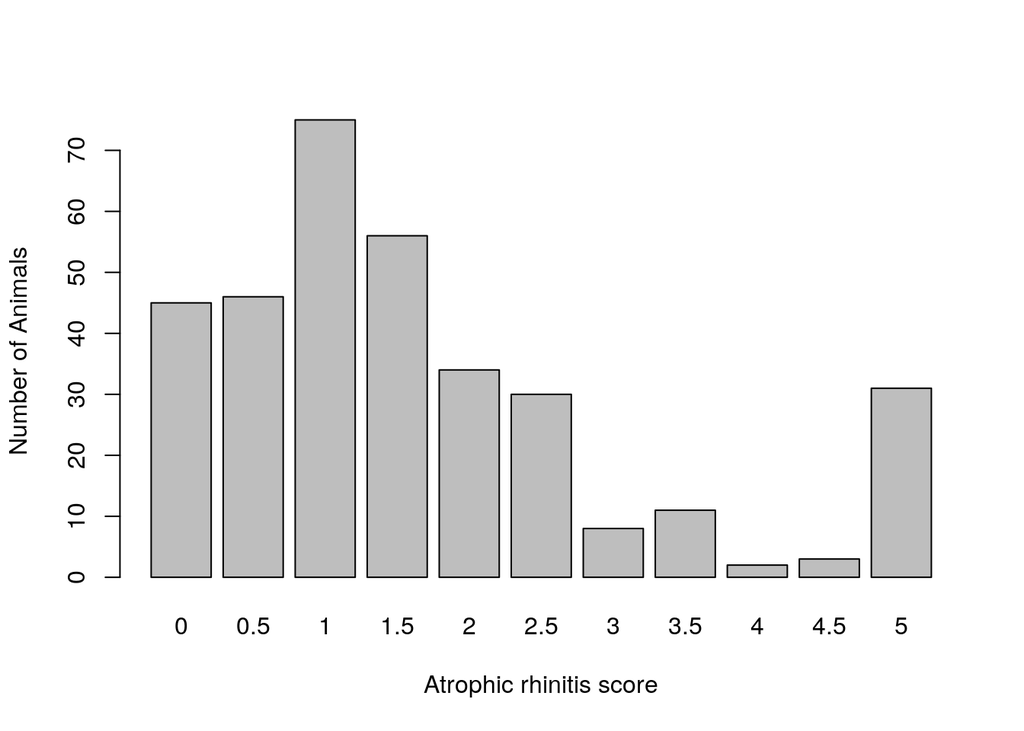

```r
barplot(counts,
        xlab = "Atrophic rhinitis score",
        ylab = "Number of Animals")
```

```r
counts <- table(pig_adg$pn, pig_adg$ar)
counts
```

```
                         0 0.5  1 1.5  2 2.5  3 3.5  4 4.5  5
  no pneumonia          25  28 36  24 10  11  3   3  2   1 12
  mild-severe pneumonia 20  18 39  32 24  19  5   8  0   2 19
```

Now use the `barplot` function to generate a plot

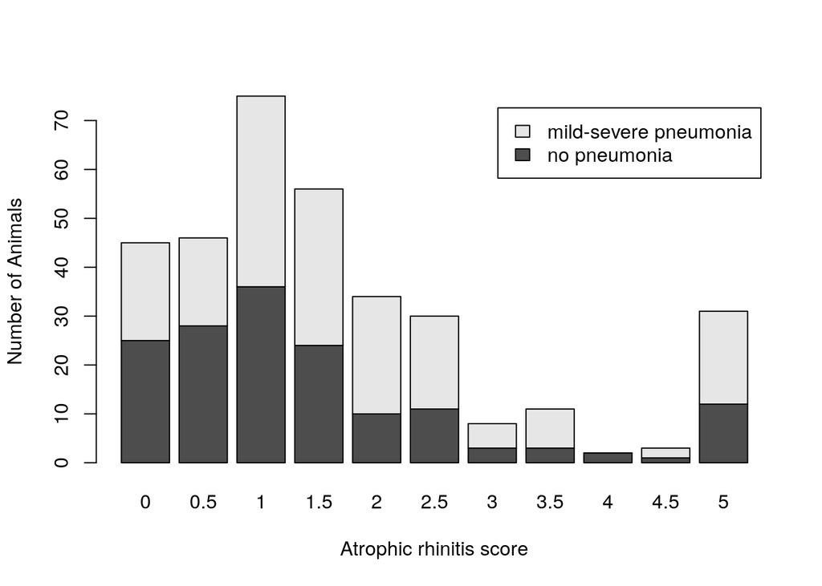

```r
barplot(counts,
        xlab = "Atrophic rhinitis score",
        ylab = "Number of Animals",
        legend = rownames(counts))
```

Maybe, (like me) you hate stacked bar plots so you want a side-by-side plot instead.

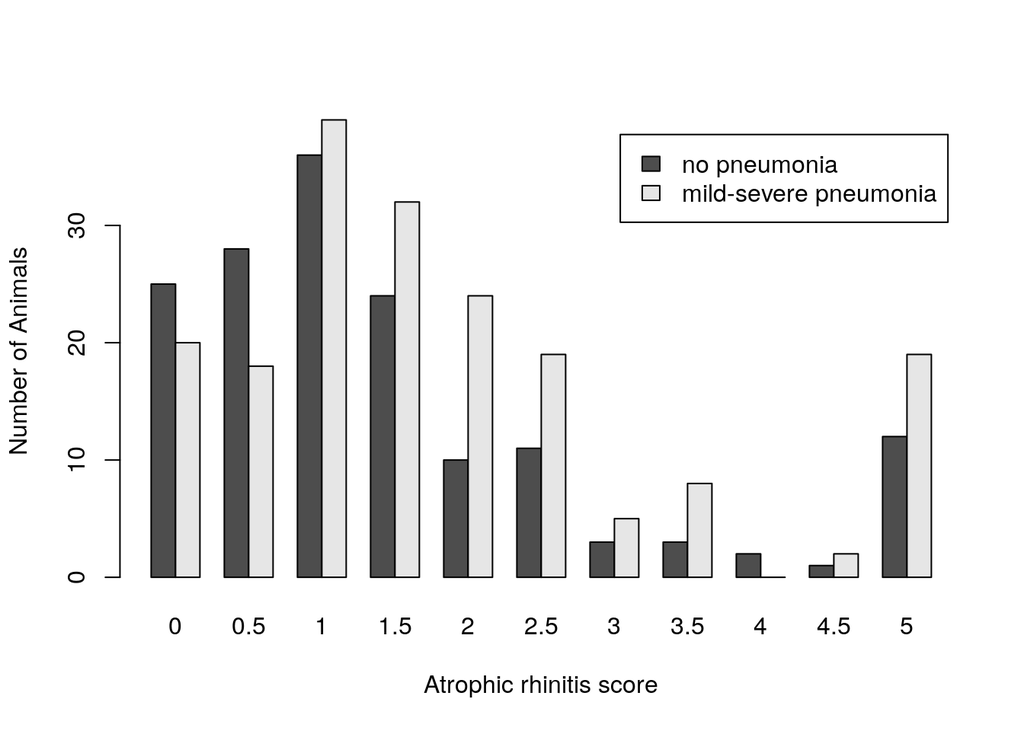

```r
barplot(counts,
        xlab = "Atrophic rhinitis score",
        ylab = "Number of Animals",
        legend = rownames(counts), beside = TRUE)
```

And you want some colour:

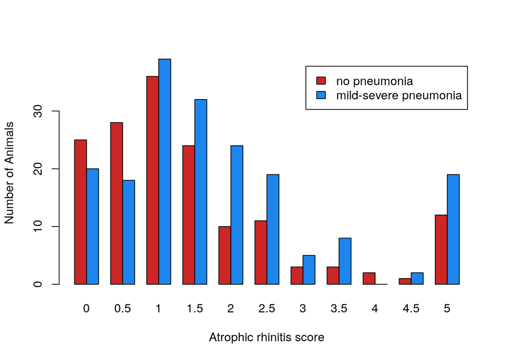

```r
barplot(counts,
        xlab   = "Atrophic rhinitis score",
        ylab   = "Number of Animals",
        legend = rownames(counts),
        col    = c("firebrick3", "dodgerblue2"),
        beside = TRUE)
```

## The boxplot

The box plot and parallel box plot lends itself well to summarizing continuous data over categories. So we can look at 1 variable or 2.

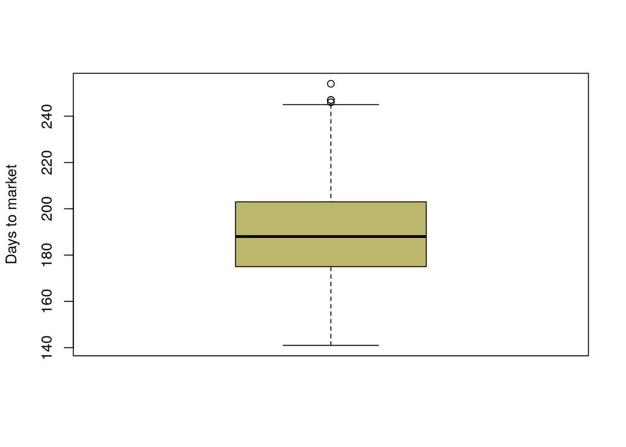

```r
boxplot(pig_adg$dtm,
        ylab = "Days to market", col = "darkkhaki")
```

And over the atrophic rhinitis score

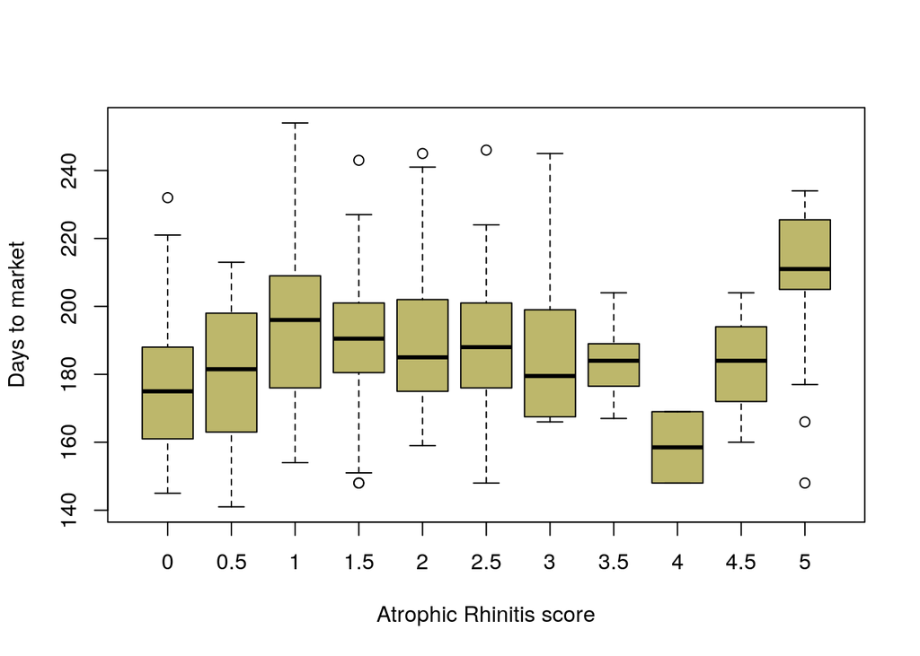

```r
boxplot(pig_adg$dtm ~ pig_adg$ar,
        ylab = "Days to market", col = "darkkhaki",
        xlab = "Atrophic Rhinitis score")
```

Note that often you can express yourself in formula notation the same way you do when specify regression models.

These are the basic plot types. Of course you can produce, surface plots, maps, 3d plots…. Pretty much anything that you can dream up. But most of the time you will find the plots above to be sufficient to help you understand many datasets.

# Now you try

Build a line graph with Days to market on the y-axis, Average daily gain on the x-axis. Plot two separate lines, one for males and one for females

We’ll generate linear model and predictions first, then you do the graph:

```r
model <- lm(formula = dtm ~ adg + sex, data = pig_adg)
predict_data <- data.frame(
    expand.grid("adg" = seq(min(pig_adg$adg), max(pig_adg$adg)),
                "sex" = factor(c(0,1), levels = c(0,1), labels = c("female", "male"))))

predict_data$prediction_dtm <- predict(model, predict_data)
```

Now use the `predict_data` data frame to make your plot. **HINT** : Generate the plot with just one sex and then add the other. You will find that this seems a little tedious and we will later look at the notation in `ggplot2` which will make the production of this type of graph slightly easier.